# CS587 - Assignment 5 part 1

## Tracking and Improving the Sofwtare Project Quality

## Defect Removal Effectiveness

## Defect Removal Effectiveness for every phase and the overall defect removal effectiveness

## Neha Ramesh Gawali A20523722

### Deliverables:

1. Your PDF document for the analysis report.
2. Your IPYNB script with the Name DRE_QM.ipynb that has your

source code and output 3. Your HTML document for your IPYNB script 4. Your 10 minutes Panopto Video Recording of Your IPYNC script live demo/run

## High Level Description:

After the initial release, R1, of the software product XYZ, the project manager for project XYZ attempted to track and improve the quality of the subsequent releases of the software product by adding more engineers to work on the review and inspection tasks in releases R2 and R4, and extending the duration by 10% of every development task by lowering the productivity rate of the engineer per unit of time (daily/weekly) in releases R3 and R5. The data, in Appendix A, represent the number of defects injected, removed, and escaped for the different tasks in every release.

In this assignment, you will execute 5 experiments to assess the quality of the sofwtare project using different methods utilized by the project manager to track and improve the software project quality.

The project manager, attempted to utlize the following methods to improve the quality of the software product delivered in the different releases of the software product:

1. Increase the duration of the task by 10%
2. Increase the number of reviewers on the review task from 4 to 5.

```python
import pandas as pd
import numpy as np
import matplotlib.pyplot as plt
from pandas import DataFrame
%matplotlib inline
import warnings
warnings.filterwarnings('ignore')
```

```python
matrix_defects_originationdetection_phase_R1 = pd.read_excel('Release_R1Matrix.xlsx', engine = 'openpyxl')
matrix_defects_originationdetection_phase_R2 = pd.read_excel('Release_R2Matrix.xlsx', engine = 'openpyxl')
matrix_defects_originationdetection_phase_R3 = pd.read_excel('Release_R3Matrix.xlsx', engine = 'openpyxl')
matrix_defects_originationdetection_phase_R4 = pd.read_excel('Release_R4Matrix.xlsx', engine = 'openpyxl')
matrix_defects_originationdetection_phase_R5 = pd.read_excel('Release_R5Matrix.xlsx', engine = 'openpyxl')
```

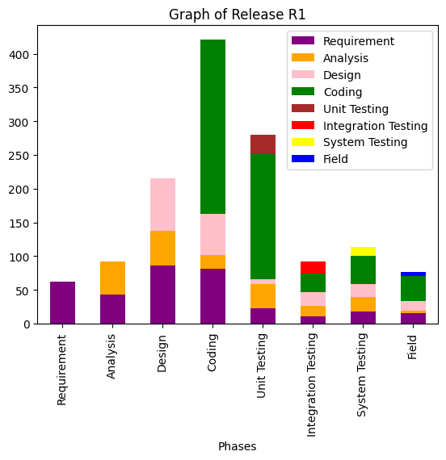

```python
matrix_defects_originationdetection_phase_R1.plot(x='Phases', kind='bar',title='Graph of Release R1',stacked=True,color=['purple', 'orange', 'pink', 'green', 'brown','red','yellow','blue'])
```

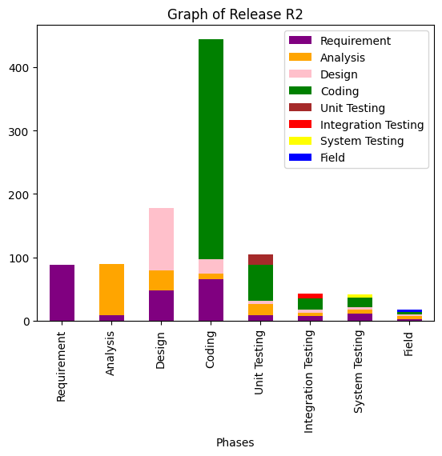

```python
matrix_defects_originationdetection_phase_R2.plot(x='Phases', kind='bar',title='Graph of Release R2',stacked=True,color=['purple', 'orange', 'pink', 'green', 'brown','red','yellow','blue'])
```

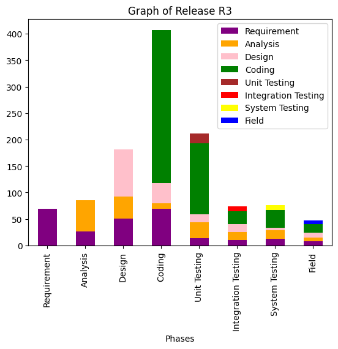

```python
matrix_defects_originationdetection_phase_R3.plot(x='Phases', kind='bar',title='Graph of Release R3',stacked=True,color=['purple', 'orange', 'pink', 'green', 'brown','red','yellow','blue'])
```

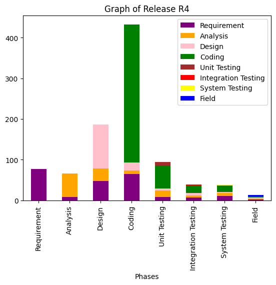

```python
matrix_defects_originationdetection_phase_R4.plot(x='Phases', kind='bar',title='Graph of Release R4',stacked=True,color=['purple', 'orange', 'pink', 'green', 'brown','red','yellow','blue'])
```

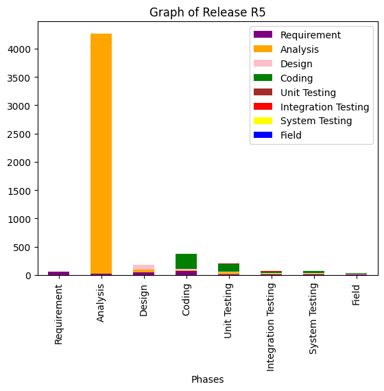

```python
matrix_defects_originationdetection_phase_R5.plot(x='Phases', kind='bar',title='Graph of Release R5',stacked=True,color=['purple', 'orange', 'pink', 'green', 'brown','red','yellow','blue'])
```

### Create the functions to calculate the defect removal effectiveness for every phase & the overall defect removal effectiveness

using following formulas:

- Defect Removal Effectiveness for development task = (Defects removed in current step / (Defects existing on step entry + Defects injected in current step)) * 100%
- Defect Removal Effectiveness for testing task = (Defects removed in current phase / (Defects removed in current phase + Defects removed in subsequent phases)) * 100%

```python
def calDefectRemovalEffectiveness(val):
    val["Detected"] = val.sum(axis=1)
    val["Injected"] = val.iloc[0:8, 1:9].sum(axis=0).tolist()
    val["Escaped"]= val["Injected"] - val["Detected"]

    for i in range(1, len(val)):
        val["Escaped"][i] += val["Escaped"][i-1]

    val["DefectsOnStepEntry"] = val["Escaped"]
    val["DefectsOnStepEntry"][0] = 0

    for i in range(1, len(val)):
        val["DefectsOnStepEntry"][i] = val["Escaped"][i-1]

    val["DRE"] = val["Escaped"]

    for i in range(0, 4):
        val.loc[i, "DRE"] = val.loc[i, "Detected"] / (val.loc[i, "Injected"] + val.loc[i, "DefectsOnStepEntry"]) * 100

    for i in range(4, len(val)-1):
        detected_sum = val.loc[i+1:, "Detected"].sum()
        val.loc[i, "DRE"] = val.loc[i, "Detected"] / (val.loc[i, "Detected"] + detected_sum) * 100

    val.loc[7, "DRE"] = np.nan

    return val
```

```python
calDefectRemovalEffectiveness(matrix_defects_originationdetection_phase_R1)
```

|  | Phases | Requirement | Analysis | Design | Coding | Unit Testing | Integration Testing | System Testing | Field | Detected | Injected | Escaped | DefectsOnStepEntry | DRE |
| --- | --- | --- | --- | --- | --- | --- | --- | --- | --- | --- | --- | --- | --- | --- |
| 0 | Requirement | 62 | NaN | NaN | NaN | NaN | NaN | NaN | NaN | 62.0 | 340.0 | 278.0 | 0.0 | 18.235294 |
| 1 | Analysis | 43 | 49.0 | NaN | NaN | NaN | NaN | NaN | NaN | 92.0 | 195.0 | 381.0 | 278.0 | 19.450317 |
| 2 | Design | 86 | 51.0 | 78.0 | NaN | NaN | NaN | NaN | NaN | 215.0 | 202.0 | 368.0 | 381.0 | 36.878216 |
| 3 | Coding | 81 | 21.0 | 61.0 | 258.0 | NaN | NaN | NaN | NaN | 421.0 | 550.0 | 497.0 | 368.0 | 45.860566 |
| 4 | Unit Testing | 23 | 35.0 | 8.0 | 185.0 | 29.0 | NaN | NaN | NaN | 280.0 | 29.0 | 246.0 | 497.0 | 49.822064 |
| 5 | Integration Testing | 11 | 15.0 | 21.0 | 27.0 | NaN | 18.0 | NaN | NaN | 92.0 | 18.0 | 172.0 | 246.0 | 32.624113 |
| 6 | System Testing | 18 | 21.0 | 19.0 | 43.0 | NaN | NaN | 13.0 | NaN | 114.0 | 13.0 | 71.0 | 172.0 | 60.000000 |
| 7 | Field | 16 | 3.0 | 15.0 | 37.0 | NaN | NaN | NaN | 5.0 | 76.0 | 5.0 | 0.0 | 71.0 | NaN |

```python
calDefectRemovalEffectiveness(matrix_defects_originationdetection_phase_R2)
```

|  | Phases | Requirement | Analysis | Design | Coding | Unit Testing | Integration Testing | System Testing | Field | Detected | Injected | Escaped | DefectsOnStepEntry | DRE |
| --- | --- | --- | --- | --- | --- | --- | --- | --- | --- | --- | --- | --- | --- | --- |
| 0 | Requirement | 88 | NaN | NaN | NaN | NaN | NaN | NaN | NaN | 88.0 | 240.0 | 152.0 | 0.0 | 36.666667 |
| 1 | Analysis | 9 | 81.0 | NaN | NaN | NaN | NaN | NaN | NaN | 90.0 | 155.0 | 217.0 | 152.0 | 29.315961 |
| 2 | Design | 48 | 31.0 | 99.0 | NaN | NaN | NaN | NaN | NaN | 178.0 | 139.0 | 178.0 | 217.0 | 50.000000 |
| 3 | Coding | 65 | 9.0 | 23.0 | 347.0 | NaN | NaN | NaN | NaN | 444.0 | 440.0 | 174.0 | 178.0 | 71.844660 |
| 4 | Unit Testing | 9 | 18.0 | 5.0 | 56.0 | 17.0 | NaN | NaN | NaN | 105.0 | 17.0 | 86.0 | 174.0 | 50.480769 |
| 5 | Integration Testing | 7 | 5.0 | 6.0 | 17.0 | NaN | 8.0 | NaN | NaN | 43.0 | 8.0 | 51.0 | 86.0 | 41.747573 |
| 6 | System Testing | 11 | 7.0 | 3.0 | 16.0 | NaN | NaN | 5.0 | NaN | 42.0 | 5.0 | 14.0 | 51.0 | 70.000000 |
| 7 | Field | 3 | 4.0 | 3.0 | 4.0 | NaN | NaN | NaN | 4.0 | 18.0 | 4.0 | 0.0 | 14.0 | NaN |

```python
calDefectRemovalEffectiveness(matrix_defects_originationdetection_phase_R3)
```

|  | Phases | Requirement | Analysis | Design | Coding | Unit Testing | Integration Testing | System Testing | Field | Detected | Injected | Escaped | DefectsOnStepEntry | DRE |
| --- | --- | --- | --- | --- | --- | --- | --- | --- | --- | --- | --- | --- | --- | --- |
| 0 | Requirement | 69 | NaN | NaN | NaN | NaN | NaN | NaN | NaN | 69.0 | 260.0 | 191.0 | 0.0 | 26.538462 |
| 1 | Analysis | 26 | 59.0 | NaN | NaN | NaN | NaN | NaN | NaN | 85.0 | 179.0 | 285.0 | 191.0 | 22.972973 |
| 2 | Design | 51 | 41.0 | 89.0 | NaN | NaN | NaN | NaN | NaN | 181.0 | 172.0 | 276.0 | 285.0 | 39.606127 |
| 3 | Coding | 69 | 11.0 | 38.0 | 289.0 | NaN | NaN | NaN | NaN | 407.0 | 497.0 | 366.0 | 276.0 | 52.652005 |
| 4 | Unit Testing | 14 | 30.0 | 15.0 | 134.0 | 19.0 | NaN | NaN | NaN | 212.0 | 19.0 | 173.0 | 366.0 | 51.833741 |
| 5 | Integration Testing | 10 | 15.0 | 16.0 | 24.0 | NaN | 9.0 | NaN | NaN | 74.0 | 9.0 | 108.0 | 173.0 | 37.563452 |
| 6 | System Testing | 13 | 16.0 | 5.0 | 33.0 | NaN | NaN | 9.0 | NaN | 76.0 | 9.0 | 41.0 | 108.0 | 61.788618 |
| 7 | Field | 8 | 7.0 | 9.0 | 17.0 | NaN | NaN | NaN | 6.0 | 47.0 | 6.0 | 0.0 | 41.0 | NaN |

```python
calDefectRemovalEffectiveness(matrix_defects_originationdetection_phase_R4)
```

|  | Phases | Requirement | Analysis | Design | Coding | Unit Testing | Integration Testing | System Testing | Field | Detected | Injected | Escaped | DefectsOnStepEntry | DRE |
| --- | --- | --- | --- | --- | --- | --- | --- | --- | --- | --- | --- | --- | --- | --- |
| 0 | Requirement | 77 | NaN | NaN | NaN | NaN | NaN | NaN | NaN | 77.0 | 228.0 | 151.0 | 0.0 | 33.771930 |
| 1 | Analysis | 9 | 57.0 | NaN | NaN | NaN | NaN | NaN | NaN | 66.0 | 128.0 | 213.0 | 151.0 | 23.655914 |
| 2 | Design | 48 | 31.0 | 107.0 | NaN | NaN | NaN | NaN | NaN | 186.0 | 142.0 | 169.0 | 213.0 | 52.394366 |
| 3 | Coding | 65 | 9.0 | 19.0 | 339.0 | NaN | NaN | NaN | NaN | 432.0 | 431.0 | 168.0 | 169.0 | 72.000000 |
| 4 | Unit Testing | 9 | 16.0 | 5.0 | 56.0 | 9.0 | NaN | NaN | NaN | 95.0 | 9.0 | 82.0 | 168.0 | 51.351351 |
| 5 | Integration Testing | 7 | 5.0 | 6.0 | 17.0 | NaN | 4.0 | NaN | NaN | 39.0 | 4.0 | 47.0 | 82.0 | 43.333333 |
| 6 | System Testing | 11 | 7.0 | 3.0 | 16.0 | NaN | NaN | 1.0 | NaN | 38.0 | 1.0 | 10.0 | 47.0 | 74.509804 |
| 7 | Field | 2 | 3.0 | 2.0 | 3.0 | NaN | NaN | NaN | 3.0 | 13.0 | 3.0 | 0.0 | 10.0 | NaN |

```python
calDefectRemovalEffectiveness(matrix_defects_originationdetection_phase_R5)
```

|  | Phases | Requirement | Analysis | Design | Coding | Unit Testing | Integration Testing | System Testing | Field | Detected | Injected | Escaped | DefectsOnStepEntry | DRE |
| --- | --- | --- | --- | --- | --- | --- | --- | --- | --- | --- | --- | --- | --- | --- |
| 0 | Requirement | 61 | NaN | NaN | NaN | NaN | NaN | NaN | NaN | 61.0 | 250.0 | 189.0 | 0.0 | 24.400000 |
| 1 | Analysis | 26 | 4239.0 | NaN | NaN | NaN | NaN | NaN | NaN | 4265.0 | 4358.0 | 282.0 | 189.0 | 93.798109 |
| 2 | Design | 51 | 41.0 | 86.0 | NaN | NaN | NaN | NaN | NaN | 178.0 | 164.0 | 268.0 | 282.0 | 39.910314 |
| 3 | Coding | 69 | 11.0 | 34.0 | 267.0 | NaN | NaN | NaN | NaN | 381.0 | 473.0 | 360.0 | 268.0 | 51.417004 |
| 4 | Unit Testing | 14 | 30.0 | 15.0 | 134.0 | 15.0 | NaN | NaN | NaN | 208.0 | 15.0 | 167.0 | 360.0 | 53.470437 |
| 5 | Integration Testing | 9 | 15.0 | 16.0 | 23.0 | NaN | 6.0 | NaN | NaN | 69.0 | 6.0 | 104.0 | 167.0 | 38.121547 |
| 6 | System Testing | 13 | 16.0 | 5.0 | 33.0 | NaN | NaN | 4.0 | NaN | 71.0 | 4.0 | 37.0 | 104.0 | 63.392857 |
| 7 | Field | 7 | 6.0 | 8.0 | 16.0 | NaN | NaN | NaN | 4.0 | 41.0 | 4.0 | 0.0 | 37.0 | NaN |

# Overall DRE

```python
Overall_DefectRemovalEffectiveness_R1 = (1 - (matrix_defects_originationdetection_phase_R1["Detected"][7] / matrix_defects_originationdetection_phase_R1.iloc[0:8, 9:10].sum())) * 100
Overall_DefectRemovalEffectiveness_R1
```

```
Detected    94.378698
dtype: float64
```

```python
Overall_DefectRemovalEffectiveness_R2 = (1 - (matrix_defects_originationdetection_phase_R2["Detected"][7] / matrix_defects_originationdetection_phase_R2.iloc[0:8, 9:10].sum())) * 100
Overall_DefectRemovalEffectiveness_R2
```

```
Detected    98.214286
dtype: float64
```

```python
Overall_DefectRemovalEffectiveness_R3 = (1 - (matrix_defects_originationdetection_phase_R3["Detected"][7] / matrix_defects_originationdetection_phase_R3.iloc[0:8, 9:10].sum())) * 100
Overall_DefectRemovalEffectiveness_R3
```

```
Detected    95.916594
dtype: float64
```

```python
Overall_DefectRemovalEffectiveness_R4 = (1 - (matrix_defects_originationdetection_phase_R4["Detected"][7] / matrix_defects_originationdetection_phase_R4.iloc[0:8, 9:10].sum())) * 100
Overall_DefectRemovalEffectiveness_R4
```

```
Detected    98.625793
dtype: float64
```

```python
Overall_DefectRemovalEffectiveness_R5 = (1 - (matrix_defects_originationdetection_phase_R5["Detected"][7] / matrix_defects_originationdetection_phase_R5.iloc[0:8, 9:10].sum())) * 100
Overall_DefectRemovalEffectiveness_R5
```

```
Detected    99.222601
dtype: float64
```